# Trajectory Analysis with Diffusion Pseudotime

The beauty of single-cell RNA-seq is the ability to delineate the cell state of each single-cell. This brings a novel advantage when considering developmental trajectories during organ development or cell differentiation. The reason for this is that biological processes are not always in synchrony. In other words, not all cells will exist at the same stage of differentiation. In that regard, a sample that is sequenced could contain the entire spectrum of cells between early to late stages of differention. To quantitate the measure of biological progress outside of defined time-points, a new metric called ‘pseudotime’ was introduced, which is defined as a distance metric between the ‘starting’ cell and ‘ending’ cell along the trajectory.

In this example, we will be using the [HSMM dataset](http://www.bioconductor.org/packages/release/data/experiment/html/HSMMSingleCell.html) of differentiating myoblasts developed by [Trapnell et al.](https://www.ncbi.nlm.nih.gov/pmc/articles/PMC4122333/). The data is already FPKM normalized so we will add a pseudocount and log-transform the data. Here we will generate a [SingleCellExperiment](https://bioconductor.org/packages/release/bioc/html/SingleCellExperiment.html) object to contain our expression matrix.

```r
library(HSMMSingleCell)
library(SingleCellExperiment)
data(HSMM_expr_matrix)
data(HSMM_sample_sheet)
m = log10(HSMM_expr_matrix + 1)
HSMM <- SingleCellExperiment(assay=list(logcounts = m), colData = HSMM_sample_sheet)
```

First, let’s run a PCA and visualize it to see if we can delineate the different cell states. Here we have `Hours` as our cell state metadata.

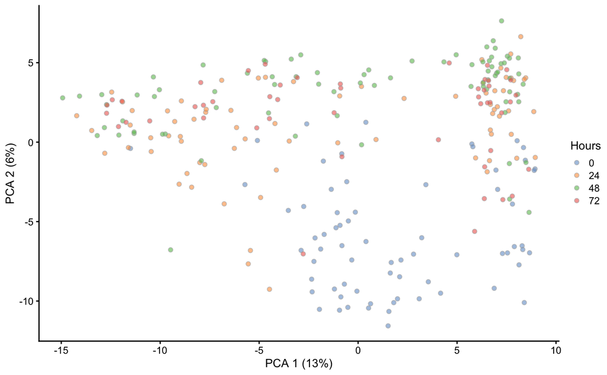

```r
plotReducedDim(HSMM, dimred="PCA", colour_by="Hours")
```

We can order each cell using the first principal component.

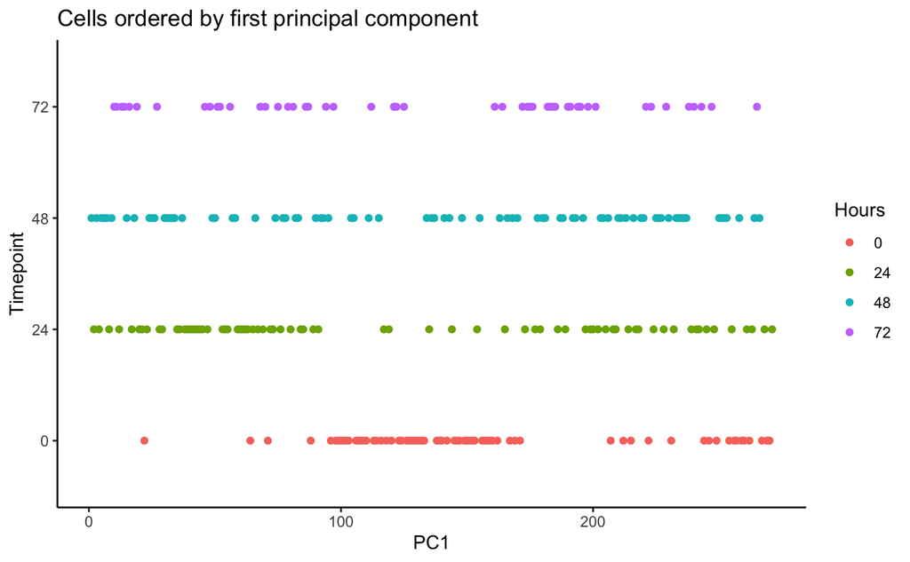

```r
pca <- reducedDim(HSMM, type = 'PCA')

HSMM$pseudotime_PC1 <- rank(pca[,1])
ggplot(as.data.frame(colData(HSMM)), aes(x = pseudotime_PC1, y = Hours,
                                             colour = Hours)) +
    geom_point() + theme_classic() +
    xlab("PC1") + ylab("Timepoint") +
    ggtitle("Cells ordered by first principal component")
```

[Haghverdi et al.](https://www.nature.com/articles/nmeth.3971.pdf?origin=ppub) developed a method called ‘Diffusion Maps’ to infer the temporal order of differentiating cells by modeling it as a diffusion process. Diffusion maps is a nonlinear method that could better resolve complex trajectories and branching than linear methods such as PCA. This method has been implemented in the R packaged [destiny](http://bioconductor.org/packages/release/bioc/html/destiny.html).

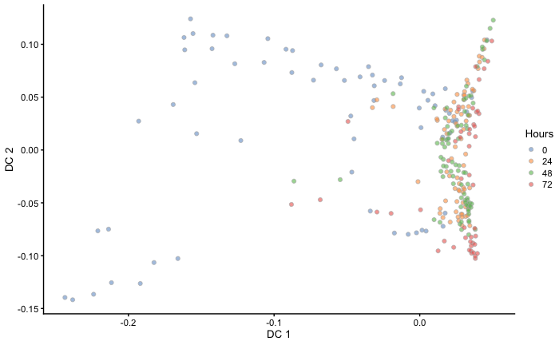

```r
library(destiny)
#  Prepare a counts matrix with labeled rows and columns.
matrix <- assay(HSMM, i = 'logcounts')

# Make a diffusion map.
dm <- DiffusionMap(t(matrix), n_pcs = 50)
reducedDim(HSMM, type = 'DC') <- dm@eigenvectors
plotReducedDim(HSMM, dimred="DC", colour_by="Hours")
```

AS you can see, the temporal ordering of the cells is better resolved in the diffusion map as opposed to PCA. In addition, it looks like there are two terminal branches which actually reflects the outcome from the original article. Next, we can try ordering the cells like we did before by ranking the eigenvectors and seeing if the cells separate based on time.

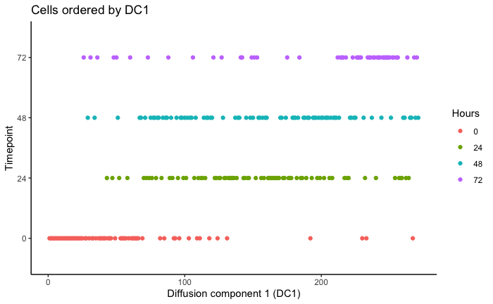

```r
# Try plotting higher diffusion components against one another.

# Next, let us use the first diffusion component (DC1) as a measure of pseudotime.
# How does the separation by cell stage look?
HSMM$pseudotime_diffusionmap <- rank(eigenvectors(dm)[,1])   # rank cells by their dpt
ggplot(as.data.frame(colData(HSMM)),
       aes(x = pseudotime_diffusionmap,
           y = Hours, color = Hours)) + geom_point() + theme_classic() +
    xlab("Diffusion component 1 (DC1)") + ylab("Timepoint") +
    ggtitle("Cells ordered by DC1")
```

It looks like we can at least resolve the earliest time-point (0 hours) and there is some separation with the final time-point (72 hours). Let’s compare with the original pseudotime by Trapnell et al.

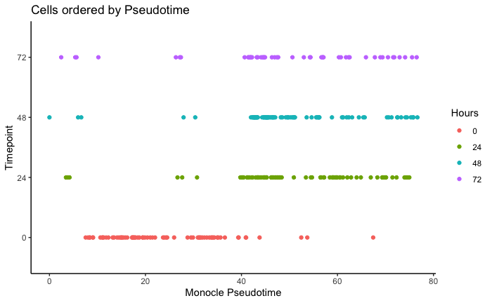

```r
# Try plotting higher diffusion components against one another.

# Next, let us use the first diffusion component (DC1) as a measure of pseudotime.
# How does the separation by cell stage look?
ggplot(as.data.frame(colData(HSMM)),
       aes(x = Pseudotime,
           y = Hours, color = Hours)) + geom_point() + theme_classic() +
    xlab("Monocle Pseudotime") + ylab("Timepoint") +
    ggtitle("Cells ordered by Pseudotime")
```

Now let’s calculate the Diffusion Pseudotime (DPT) by setting the first ranked cell as the root cell.

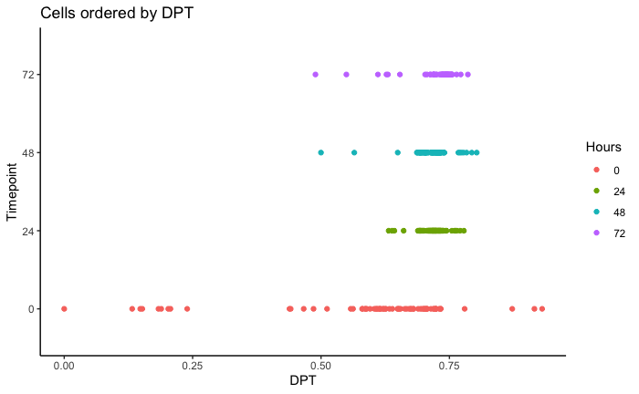

```r
index <- 1:length(HSMM$pseudotime_diffusionmap)
dpt <- DPT(dm, tips = index[HSMM$pseudotime_diffusionmap == 1])
HSMM$dpt <- dpt$dpt

ggplot(as.data.frame(colData(HSMM)),
       aes(x = dpt,
           y = Hours, color = Hours)) + geom_point() + theme_classic() +
    xlab("DPT") + ylab("Timepoint") +
    ggtitle("Cells ordered by DPT")
```

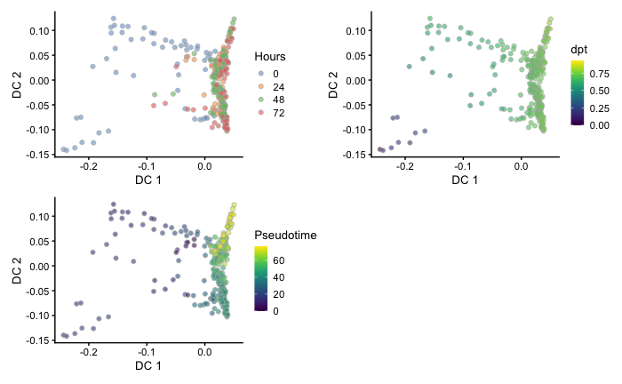